# Regresión Con Variables Categóricas

# 1 Introducción

En este análisis, exploramos cómo incluir variables categóricas en un modelo de regresión lineal. Además, validaremos los supuestos del modelo, estudiaremos la colinealidad y realizaremos predicciones.

# 2 Variables cuantitativas y cualitativas en regresión

En un análisis de regresión, las variables explicativas utilizadas suelen ser cuantitativas, lo que significa que se miden en una escala numérica bien definida. Por ejemplo:

- temperatura
- la distancia
- la presión
- el ingreso.

Sin embargo, en muchos casos también se requiere incluir variables cualitativas o categóricas como predictores. Estas variables no tienen una escala numérica natural, pero aun así pueden influir sobre la variable respuesta. Algunos ejemplos comunes son:

- sexo (masculino o femenino)
- estado laboral (empleado o desempleado)
- turno de trabajo (diurno, mixto o nocturno)
- operador que realiza un proceso

Para incorporar estas variables categóricas en un modelo de regresión, se recurre al uso de variables indicadoras (también llamadas variables ficticias o dummy variables).

# 3 Variables dummy.

Estas variables permiten codificar los distintos niveles de una categoría como variables binarias (0 o 1), facilitando su inclusión en el modelo y permitiendo medir el efecto de cada categoría sobre la variable de interés.

## 3.1 Ejemplo: Vida útil de una herramienta de corte

Ejemplo extraído del libro (Montgomery, Peck, and Vining 2006).

Un ingeniero mecánico desea estudiar cómo se relaciona la vida útil de un buril (una herramienta que corta con precisión materiales metálicos) con dos variables:

- la velocidad del torno, medida en revoluciones por minuto (rpm)
- el tipo de buril utilizado, que puede ser de tipo A o tipo B

El objetivo es construir un modelo de regresión lineal que permita predecir la vida útil del buril a partir de la velocidad del torno y del tipo de herramienta utilizada.

# 4 Lectura de los datos

```r
datos <- read.csv("./TipoHerramienta.csv")
```

# 5 Scatter plot

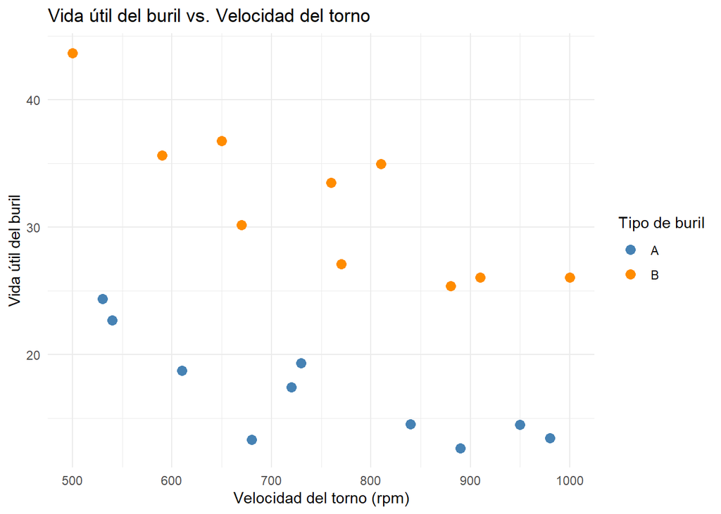

```r
ggplot(datos, aes(x = x1, y = y, color = x2)) +
  geom_point(size = 3) +
  labs(
    title = "Vida útil del buril vs. Velocidad del torno",
    x = "Velocidad del torno (rpm)",
    y = "Vida útil del buril",
    color = "Tipo de buril"
  ) +
  theme_minimal() +
  scale_color_manual(values = c("A" = "steelblue", "B" = "darkorange"))
```

# 6 Codificación de las variables categóricas con variables dummy

Observemos que la velocidad es una variable cuantitativa ($X_1$), mientras que el tipo de buril es una variable cualitativa ($X_2$) con dos niveles. Para poder incluir esta variable categórica en el análisis de regresión, la codificaremos mediante la incorporación de una variable indicadora, también llamada dummy, que tomará los valores:

$$\begin{equation}
X_2=\left\{\begin{array}{l}
0 \text { si la observación procede de la herramienta tipo } \mathrm{A}
\\
1 \text { si la observación procede de la herramienta tipo } \mathrm{B}
\end{array}\right.
\end{equation}$$

*Observación:* La elección de los valores $0$ y $1$ para codificar los niveles de la variable cualitativa es arbitraria, pero son los más usados.

# 7 Modelo teórico propuesto

$$\begin{equation}
Y=\beta_0+\beta_1 X_{1}+\beta_2 X_{2}+\varepsilon \text{ con }
\varepsilon \sim N(0,\sigma^2).
\end{equation}$$

## 7.1 Modelo para el primer valor de la variable categórica

- $X_2=0$

$$\begin{align}
Y&=\beta_0+\beta_1 X_{1}+\beta_2 * 0+\varepsilon\\
Y&=\beta_0+\beta_1 X_{1}+\varepsilon
\end{align}$$

## 7.2 Modelo para el segundo valor de la variable categórica

- $X_2=1$

$$\begin{align}
Y&=\beta_0+\beta_1 X_{1}+\beta_2 * 1+\varepsilon\\
Y&=\beta_0+\beta_1 X_{1}+\beta_2 +\varepsilon\\
Y&=(\beta_0+\beta_2)+\beta_1 X_{1} +\varepsilon
\end{align}$$

*Observación:*

- Ambos modelos tienen la misma pendiente $\beta_1$, pero difieren en la ordenada al origen.
- Son rectas paralelas.

# 8 Ajuste del Modelo de Regresión

```r
modelo <- lm(y ~ x1 + x2, data = datos)
summary(modelo)
```

```
##
## Call:
## lm(formula = y ~ x1 + x2, data = datos)
##
## Residuals:
##     Min      1Q  Median      3Q     Max
## -5.5527 -1.7868 -0.0016  1.8395  4.9838
##
## Coefficients:
##             Estimate Std. Error t value Pr(>|t|)
## (Intercept) 36.98560    3.51038  10.536 7.16e-09 ***
## x1          -0.02661    0.00452  -5.887 1.79e-05 ***
## x2B         15.00425    1.35967  11.035 3.59e-09 ***
## ---
## Signif. codes:  0 '***' 0.001 '**' 0.01 '*' 0.05 '.' 0.1 ' ' 1
##
## Residual standard error: 3.039 on 17 degrees of freedom
## Multiple R-squared:  0.9003, Adjusted R-squared:  0.8886
## F-statistic: 76.75 on 2 and 17 DF,  p-value: 3.086e-09
```

# 9 Modelo obtenido

```r
beta0=modelo$coefficients[1]
beta1=modelo$coefficients[2]
beta2=modelo$coefficients[3]
beta0
```

```
## (Intercept)
##     36.9856
```

```r
beta1
```

```
##          x1
## -0.02660723
```

```r
beta2
```

```
##      x2B
## 15.00425
```

$$Y= 36.986-0.0267 X_1 + 15.0047 X_2$$

# 10 Interpretación de los parámetros

- $\beta_1$ indica el cambio en la duración promedio de las herramientas cuando aumento en $1 \ rpm$ la velocidad.
- $\beta_2$ indica el cambio en la duración promedio de las herramientas cuando cambio de la herramienta tipo $A$ a la tipo $B$.

# 11 Visualización del modelo ajustado por grupo

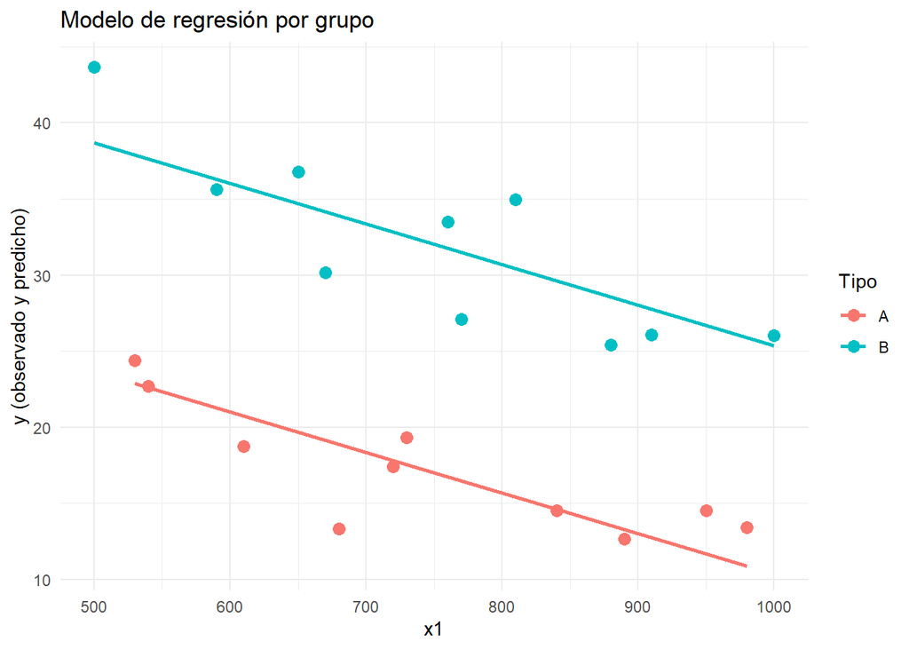

```r
## 6.1 Visualización del modelo ajustado por grupo

# Predicciones sobre el dataset original
datos_pred <- datos %>%
  mutate(pred = predict(modelo))

# Gráfico de puntos con regresión por grupo
ggplot(datos_pred, aes(x = x1, y = y, color = x2)) +
  geom_point(size = 3) +
  geom_line(aes(y = pred), linewidth = 1) +
  labs(
    title = "Modelo de regresión por grupo",
    x = "x1",
    y = "y (observado y predicho)",
    color = "Tipo"
  ) +
  theme_minimal()
```

## 11.1 ¿Qué muestra este gráfico?

- Los puntos representan los valores de la variable respuesta $Y$.
- Las líneas son las rectas de regresión ajustadas por grupo (tipo).
- Se puede ver cómo cambia la relación entre x1 y y según el tipo.

# 12 Verificación de supuestos

## 12.1 Plots de diagnóstico

- Residuos vs. predichos

```r
# Crear dataframe con residuos y valores ajustados
diagnostico <- augment(modelo)
diagnostico
```

```
## # A tibble: 20 × 9
##        y    x1 x2    .fitted  .resid  .hat .sigma   .cooksd .std.resid
##    <dbl> <int> <chr>   <dbl>   <dbl> <dbl>  <dbl>     <dbl>      <dbl>
##  1  18.7   610 A        20.8 -2.03   0.142   3.09 0.0284       -0.719
##  2  14.5   950 A        11.7  2.81   0.191   3.03 0.0833        1.03
##  3  17.4   720 A        17.8 -0.398  0.102   3.13 0.000721     -0.138
##  4  14.5   840 A        14.6 -0.0955 0.119   3.13 0.0000505    -0.0335
##  5  13.4   980 A        10.9  2.53   0.220   3.05 0.0835        0.942
##  6  24.4   530 A        22.9  1.51   0.204   3.10 0.0264        0.555
##  7  13.3   680 A        18.9 -5.55   0.110   2.77 0.154        -1.94
##  8  22.7   540 A        22.6  0.0923 0.195   3.13 0.0000923     0.0338
##  9  12.7   890 A        13.3 -0.625  0.145   3.13 0.00280      -0.222
## 10  19.3   730 A        17.6  1.76   0.101   3.10 0.0139        0.610
## 11  30.2   670 B        34.2 -4.00   0.116   2.95 0.0855       -1.40
## 12  27.1   770 B        31.5 -4.41   0.101   2.91 0.0873       -1.53
## 13  25.4   880 B        28.6 -3.18   0.135   3.01 0.0657       -1.12
## 14  26.0  1000 B        25.4  0.667  0.234   3.13 0.00640       0.251
## 15  33.5   760 B        31.8  1.72   0.100   3.10 0.0132        0.597
## 16  35.6   590 B        36.3 -0.672  0.159   3.13 0.00367      -0.241
## 17  26.1   910 B        27.8 -1.71   0.154   3.10 0.0226       -0.611
## 18  36.8   650 B        34.7  2.08   0.124   3.08 0.0253        0.733
## 19  35.0   810 B        30.4  4.51   0.107   2.90 0.0985        1.57
## 20  43.7   500 B        38.7  4.98   0.243   2.79 0.379         1.88
```

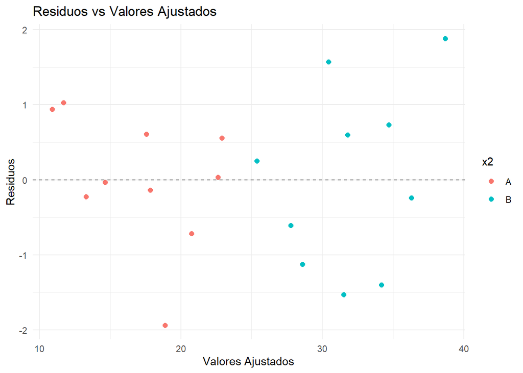

```r
# Gráfico de residuos vs ajustados
ggplot(diagnostico, aes(.fitted, .std.resid,color=x2)) +
  geom_point(size = 2) +
  geom_hline(yintercept = 0, linetype = "dashed", color = "gray40") +
  labs(
    title = "Residuos vs Valores Ajustados",
    x = "Valores Ajustados",
    y = "Residuos"
  ) +
  theme_minimal()
```

Los residuos de la herramienta tipo “B” muestran un poco más dispersión que los del tipo “A”. Puede haber un problema moderado de desigualdad de varianza.

- Normalidad de residuos

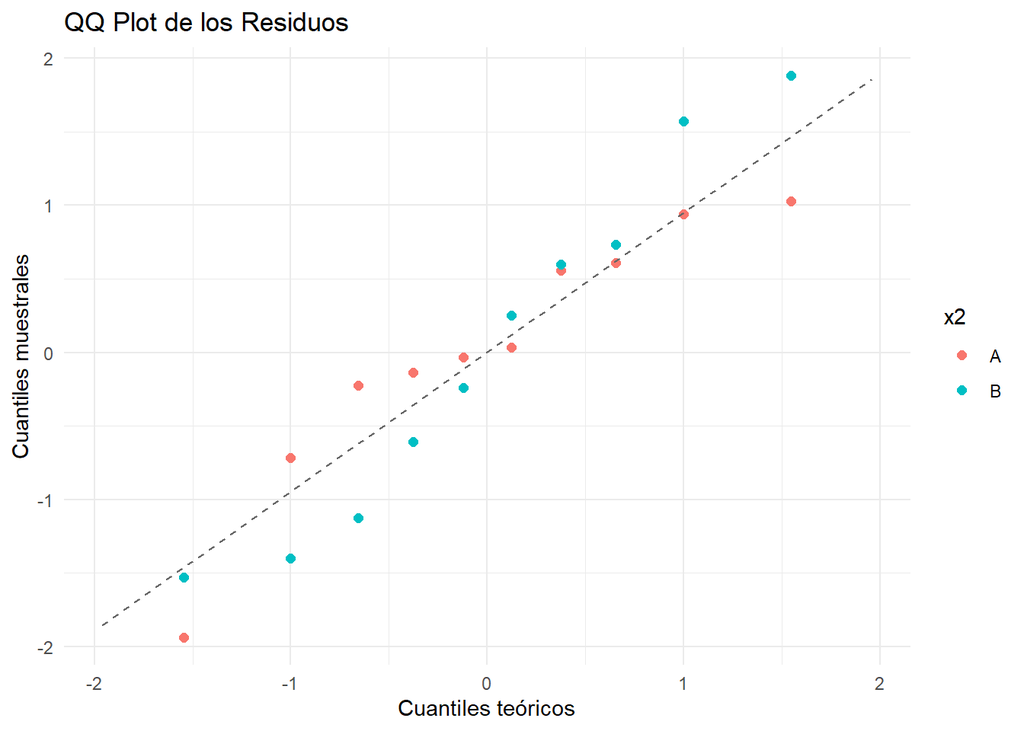

```r
# Crear el QQ plot con ggplot2
ggplot(diagnostico, aes(sample = .std.resid, color=x2)) +
  stat_qq( size = 2) +
  stat_qq_line(color = "gray40", linetype = "dashed") +
  labs(
    title = "QQ Plot de los Residuos",
    x = "Cuantiles teóricos",
    y = "Cuantiles muestrales"
  ) +
  theme_minimal()
```

# 13 Multicolinealidad

```r
vif(modelo)
```

```
##       x1       x2
## 1.000542 1.000542
```

# 14 Análisis de puntos influyentes

## 14.1 Levarge

```r
n=dim(datos)[1]
p=3
hatvalues(modelo)[hatvalues(modelo)>2*p/n]
```

```
## named numeric(0)
```

- No se observan puntos con alto leverage

## 14.2 Distancia de Cook

```r
#distancias de cook
dcook <- cooks.distance(modelo)
p=3

#punto de corte
corte <- qf(0.5,p,n-p)
corte
```

```
## [1] 0.8212088
```

```r
dcook[dcook>corte]
```

```
## named numeric(0)
```

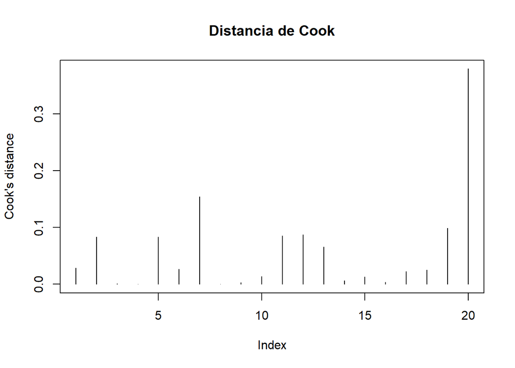

```r
# Visualizar
plot(dcook, type = "h", main = "Distancia de Cook", ylab = "Cook's distance")
abline(h = corte, col = "red", lty = 2)
```

```r
# Ver los índices de los puntos más influyentes
which(dcook >corte)
```

```
## named integer(0)
```

- No se observan puntos con alta influencia.

# 15 Salida del summary

## 15.1 $R^2$ y $R^2 ajustado$

```r
# R^2
summary(modelo)$r.squared
```

```
## [1] 0.9002884
```

```r
# R^2 ajustado
summary(modelo)$adj.r.squared
```

```
## [1] 0.8885576
```

- Ambos indican un buen ajuste.

## 15.2 Test F

```r
resumen <- summary(modelo)
pf(resumen$fstatistic[1],
   resumen$fstatistic[2],
   resumen$fstatistic[3],
   lower.tail = FALSE)
```

```
##        value
## 3.085591e-09
```

- Es un pvalor muy chico, menor a 0.05.
- Esto indica que se rechaza la hipótesis nula a nivel 0.05, es decir, el modelo de regresión es globalmente significativo.
- Al menos una de las variables explicativas contribuye a explicar la variabilidad en la respuesta.

## 15.3 Test t

- Los pvalores para testear si $\beta_0$, $\beta_1$ y $\beta_2$ son significativos son todos chicos.

```r
resumen <- summary(modelo)

# Ver la tabla de coeficientes completa:
resumen$coefficients
```

```
##                Estimate Std. Error  t value     Pr(>|t|)
## (Intercept) 36.98560119 3.51038246 10.53606 7.163380e-09
## x1          -0.02660723 0.00451972 -5.88692 1.793395e-05
## x2B         15.00425061 1.35966970 11.03522 3.586837e-09
```

```r
pvalores <- resumen$coefficients[, 4]
pvalores
```

```
##  (Intercept)           x1          x2B
## 7.163380e-09 1.793395e-05 3.586837e-09
```

- Todos los parámetros son significativos.
- Las dos variables regresoras contribuyen al modelo.

# 16 Conclusiones del summary

- el pvalor asociado a la prueba F es muy chico (3.086e-09), mucho menor que el nivel de significación usual (0.05). Por lo tanto se rechaza la hipótesis nula de que todos los coeficientes son cero.
- esto indica que el modelo de regresión es globalmente significativo, es decir, al menos una de las variables predictoras contribuye de manera significativa a explicar la vida útil del buril.
- los p valores para las hipótesis correspondientes para $\beta_1$ y $\beta_2$ también son chicos. Por lo tanto, las dos variables regresoras contribuyen al modelo.

# 17 Adecuación del modelo

De acuerdo al análisis previamente realizado, no se observan indicios de que el modelo no sea adecuado.

# 18 Intervalos de confianza para los parámetros

```r
confint(modelo)
```

```
##                   2.5 %      97.5 %
## (Intercept) 29.57934160 44.39186079
## x1          -0.03614301 -0.01707145
## x2B         12.13559830 17.87290293
```

- Recordemos que el parámetro $\beta_2$ representa el cambio promedio de la herramienta, debido a un cambio del tipo A al tipo B de herramienta.
- El intervalo de confianza del $95\%$ para el efecto del cambio de buril de tipo $A$ a tipo $B$ indica un aumento en la duración de la herramienta comprendido entre $12.135$ y $17.873$ horas.

# 19 Predicciones

```r
nuevos <- data.frame(
  x1 = c(700, 800),
  x2 = c("A", "B")
)

predict(modelo, nuevos, interval = "prediction")
```

```
##        fit      lwr      upr
## 1 18.36054 11.61986 25.10122
## 2 30.70407 23.96401 37.44412
```

# 20 Conclusiones

- El modelo permite evaluar diferencias entre los grupos A y B.
- Se verifica que el tipo de herramienta tiene un efecto significativo sobre $Y$.
- Se validaron los supuestos y se exploró la colinealidad y existencia de puntos influyentes, dando un modelo que resulta adecuado.

# 21 Justificación del uso de un modelo único con variable indicadora

Aunque es posible ajustar dos modelos de regresión separados —uno para cada tipo de buril—, se opta por utilizar un único modelo que incorpora una variable indicadora. Esta elección presenta varias ventajas:

- **Simplificación del modelo**: se obtiene una única ecuación para describir la relación entre la vida útil del buril y la velocidad del torno, considerando dos tipos de herramientas, lo cual facilita su interpretación y aplicación práctica.
- **Eficiencia en la estimación**: dado que se asume una pendiente común para ambos tipos de buril, combinar los datos permite una estimación más precisa de ese parámetro.
- **Mayor uso de la información disponible**: al no dividir la muestra, se preservan más grados de libertad para estimar la varianza del error, lo cual mejora la robustez de las inferencias estadísticas.
- **Estimación común de la varianza del error**: el modelo único permite calcular una sola estimación de la varianza, que se basa en un conjunto más amplio de datos y ofrece mayor precisión para construir intervalos de confianza y realizar contrastes.

# 22 Interacciones

En regresión, una interacción ocurre cuando el efecto de una variable independiente (por ejemplo $X_1$) sobre la variable dependiente ($Y$) cambia según el valor de otra variable independiente (por ejemplo $X_2$).

- Por ejemplo: Queremos estudiar el efecto del ejercicio físico ($X_1$) sobre el nivel de colesterol en sangre ($Y$). Este nivel podría depender de una dieta ($X_2$). Entonces, el efecto del ejercicio cambia si la persona tiene una dieta saludable o no.
- Esto quiere decir, que la pendiente cambia según si la persona sigue una dieta o no.
- Se puede modelar esta situación con una sola ecuación donde le agregamos un término de interacción.

$$\begin{equation}
Y=\beta_0+\beta_1 X_{1}+\beta_2 X_{2}+\beta_3 X_{1}X_{2}+\varepsilon
\text{ con } \varepsilon \sim N(0,\sigma^2).
\end{equation}$$

$$\begin{align}
Y=&\beta_0+\beta_1 X_{1}+\beta_2 * 0+\beta_3 X_{1}*0+\varepsilon \\
Y=&\beta_0+\beta_1 X_{1}+\varepsilon
\end{align}$$

- Tipo de buril = $B$. En este caso $X_2=1.$

$$\begin{align}
Y=&\beta_0+\beta_1 X_{1}+\beta_2 * 1+\beta_3 X_{1}*1+\varepsilon \\
Y=&\beta_0+\beta_1 X_{1}+\beta_2 +\beta_3 X_{1}+\varepsilon \\
Y=&(\beta_0+\beta_2)+(\beta_1+\beta_3) X_{1}+\varepsilon \\
\end{align}$$

- Cuando existe un término de interacción, no solo cambia la pendiente sino que también cambia la ordenada al origen.

## 22.1 Interpretación de los parámetros

- $\beta_2$ representa el cambio en la ordenada al origen cuando cambio de tipo de buril (de $A$ a $B$.)
- $\beta_3$ indica el cambio en la pendiente cuando cambio el tipo de buril.

## 22.2 Ajustar el modelo con interacción

```r
modelo_con_interaccion <- lm(y ~ x1 * x2, data = datos)
summary(modelo_con_interaccion)
```

```
##
## Call:
## lm(formula = y ~ x1 * x2, data = datos)
##
## Residuals:
##     Min      1Q  Median      3Q     Max
## -5.1750 -1.4999  0.4849  1.7830  4.8652
##
## Coefficients:
##              Estimate Std. Error t value Pr(>|t|)
## (Intercept) 32.774760   4.633472   7.073 2.63e-06 ***
## x1          -0.020970   0.006074  -3.452  0.00328 **
## x2B         23.970593   6.768973   3.541  0.00272 **
## x1:x2B      -0.011944   0.008842  -1.351  0.19553
## ---
## Signif. codes:  0 '***' 0.001 '**' 0.01 '*' 0.05 '.' 0.1 ' ' 1
##
## Residual standard error: 2.968 on 16 degrees of freedom
## Multiple R-squared:  0.9105, Adjusted R-squared:  0.8937
## F-statistic: 54.25 on 3 and 16 DF,  p-value: 1.319e-08
```

## 22.3 Visualización de la interacción

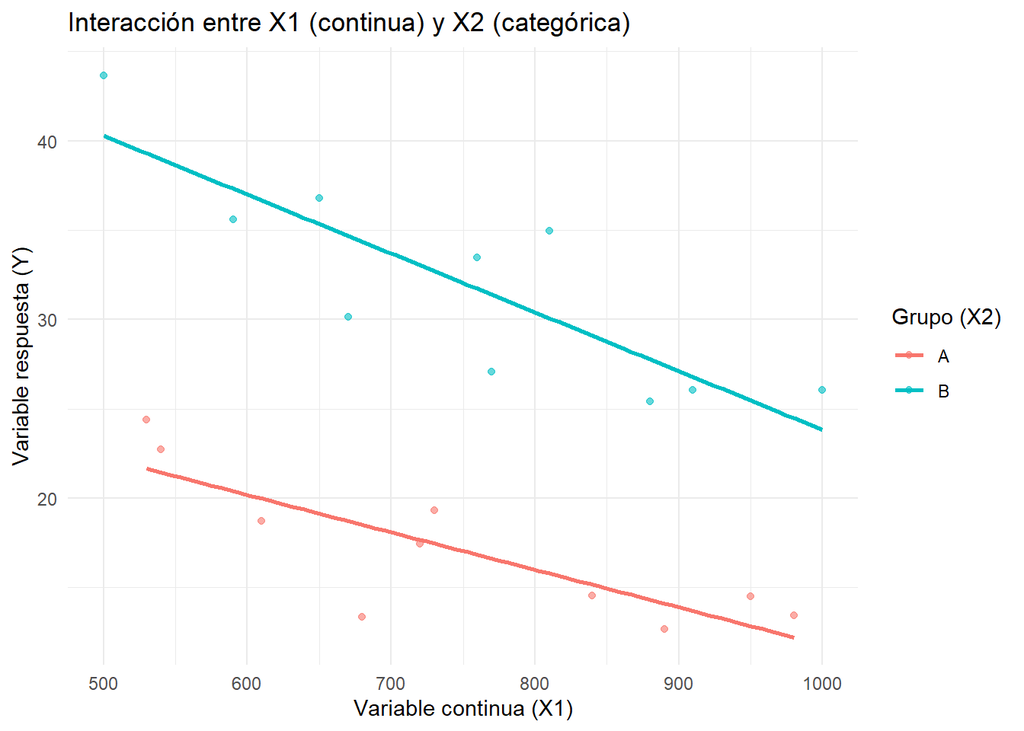

```r
ggplot(datos, aes(x = x1, y = y, color = x2)) +
  geom_point(alpha = 0.6) +
  geom_smooth(method = "lm", se = FALSE) +
  labs(title = "Interacción entre X1 (continua) y X2 (categórica)",
       x = "Variable continua (X1)",
       y = "Variable respuesta (Y)",
       color = "Grupo (X2)") +
  theme_minimal()
```

# 23 Otro ejemplo

## 23.1 Efecto del Horario de Estudio y Tipo de Enseñanza en el Rendimiento Académico (Y)

Se desea analizar cómo afectan las horas de estudio semanales y el tipo de enseñanza (presencial o virtual) al rendimiento académico de los estudiantes, medido mediante la nota final obtenida en una materia.

- Se busca determinar si:
  - Existe una diferencia en el rendimiento promedio entre los estudiantes según la modalidad.
  - El efecto de estudiar más horas varía entre la enseñanza presencial y la virtual.

## 23.2 Lectura de datos

```r
datos<-read.csv("./Virtualidad.csv")
head(datos)
```

```
##    nota horas       tipo
## 1 34.83  5.02    Virtual
## 2 44.22  5.26    Virtual
## 3 37.77  5.62    Virtual
## 4 59.93  6.05 Presencial
## 5 38.48  6.14    Virtual
## 6 61.16  6.15 Presencial
```

## 23.4 Variable tipo Factor

En $\textit{R}$, una variable tipo $\textit{factor}$ es una variable categórica que toma un número limitado y fijo de valores posibles llamados niveles. En general, se usa este tipo de variables para representar variables cualitativas, como:

- Tipo de enseñanza: Presencial, Virtual.
- Estado civil (Soltero, Casado, etc.)

## 23.5 ¿Por qué se usan variables tipo $\textit{factor}$ en $\textit{R}$?

Porque $\textit{R}$ necesita saber que una variable representa categorías (y no números) para:

- Tratarla correctamente en modelos estadísticos (como regresión).
- Etiquetar correctamente los grupos en gráficos.

## 23.6 ¿Cómo convertir una variable categórica en $\textit{factor}$?

```r
datos$tipo = factor(datos$tipo)

str(datos)
```

```
## 'data.frame':    163 obs. of  3 variables:
##  $ nota : num  34.8 44.2 37.8 59.9 38.5 ...
##  $ horas: num  5.02 5.26 5.62 6.05 6.14 6.15 6.52 6.92 7.28 7.34 ...
##  $ tipo : Factor w/ 2 levels "Presencial","Virtual": 2 2 2 1 2 1 2 1 2 2 ...
```

## 23.7 Visualización de los datos

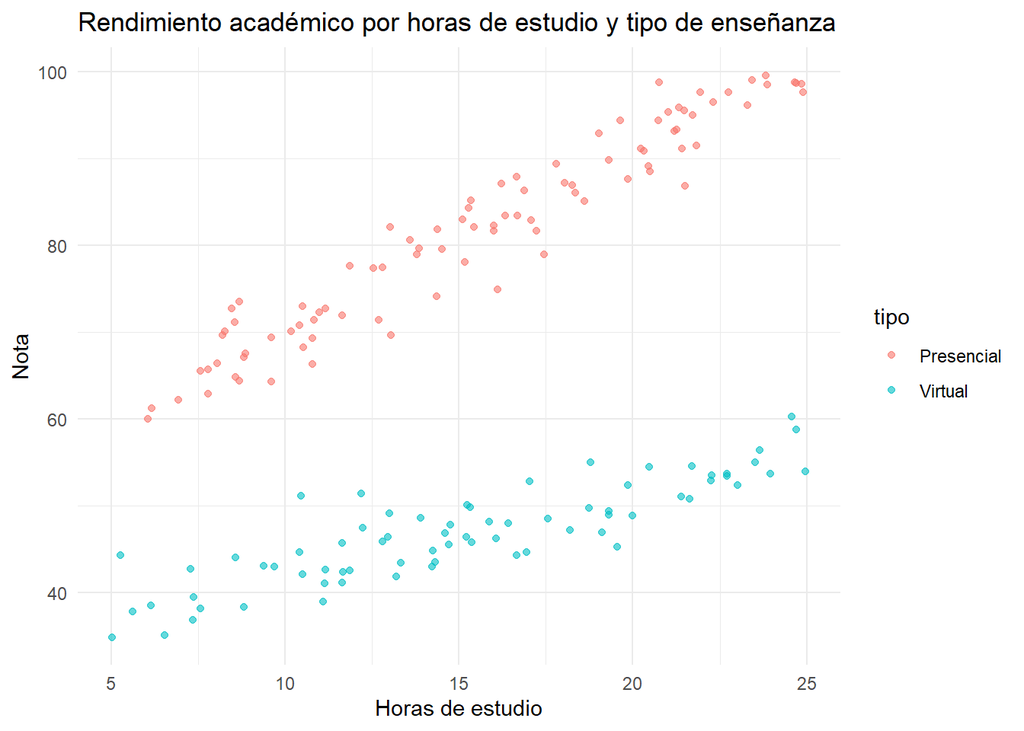

```r
library(ggplot2)

ggplot(datos, aes(x = horas, y = nota, color = tipo)) +
  geom_point(alpha = 0.6) +
  labs(title = "Rendimiento académico por horas de estudio y tipo de enseñanza",
       x = "Horas de estudio", y = "Nota") +
  theme_minimal()
```

Se observa presencia de interacción.

## 23.8 Ajuste del modelo sin interacción

```r
modelo_sin <- lm(nota ~ horas + tipo, data = datos)
summary(modelo_sin)
```

```
##
## Call:
## lm(formula = nota ~ horas + tipo, data = datos)
##
## Residuals:
##     Min      1Q  Median      3Q     Max
## -8.2979 -3.3355  0.1556  3.0083 12.3975
##
## Coefficients:
##              Estimate Std. Error t value Pr(>|t|)
## (Intercept)  57.84769    1.06785   54.17   <2e-16 ***
## horas         1.52209    0.06216   24.49   <2e-16 ***
## tipoVirtual -34.03132    0.67564  -50.37   <2e-16 ***
## ---
## Signif. codes:  0 '***' 0.001 '**' 0.01 '*' 0.05 '.' 0.1 ' ' 1
##
## Residual standard error: 4.28 on 160 degrees of freedom
## Multiple R-squared:  0.953,  Adjusted R-squared:  0.9524
## F-statistic:  1621 on 2 and 160 DF,  p-value: < 2.2e-16
```

## 23.9 Ajuste del modelo con interacción

```r
modelo_con <- lm(nota ~ horas * tipo, data = datos)
summary(modelo_con)
```

```
##
## Call:
## lm(formula = nota ~ horas * tipo, data = datos)
##
## Residuals:
##     Min      1Q  Median      3Q     Max
## -7.8180 -1.9193 -0.1532  1.9339  8.3815
##
## Coefficients:
##                    Estimate Std. Error t value Pr(>|t|)
## (Intercept)        49.77813    0.95148   52.32   <2e-16 ***
## horas               2.03969    0.05772   35.34   <2e-16 ***
## tipoVirtual       -16.39476    1.39955  -11.71   <2e-16 ***
## horas:tipoVirtual  -1.14925    0.08601  -13.36   <2e-16 ***
## ---
## Signif. codes:  0 '***' 0.001 '**' 0.01 '*' 0.05 '.' 0.1 ' ' 1
##
## Residual standard error: 2.947 on 159 degrees of freedom
## Multiple R-squared:  0.9779, Adjusted R-squared:  0.9774
## F-statistic:  2340 on 3 and 159 DF,  p-value: < 2.2e-16
```

- Se observa un cambio en los parámetros estimados del modelo. Puede evidenciar presencia de multicolinealidad.

```r
library(car)
vif(modelo_con)
```

```
## there are higher-order terms (interactions) in this model
## consider setting type = 'predictor'; see ?vif
```

```
##      horas       tipo horas:tipo
##   1.822499   9.066696   9.675682
```

- Se observa multicolinealidad debido a la interacción.
- Esto se resuelve centrando la variable regresora continua.

```r
media<-mean(datos$horas)
datos$horas_c <- datos$horas-media
modelo <- lm(nota ~ horas_c * tipo, data = datos)
summary(modelo)
```

```
##
## Call:
## lm(formula = nota ~ horas_c * tipo, data = datos)
##
## Residuals:
##     Min      1Q  Median      3Q     Max
## -7.8180 -1.9193 -0.1532  1.9339  8.3815
##
## Coefficients:
##                      Estimate Std. Error t value Pr(>|t|)
## (Intercept)          81.17736    0.30912  262.61   <2e-16 ***
## horas_c               2.03969    0.05772   35.34   <2e-16 ***
## tipoVirtual         -34.08638    0.46520  -73.27   <2e-16 ***
## horas_c:tipoVirtual  -1.14925    0.08601  -13.36   <2e-16 ***
## ---
## Signif. codes:  0 '***' 0.001 '**' 0.01 '*' 0.05 '.' 0.1 ' ' 1
##
## Residual standard error: 2.947 on 159 degrees of freedom
## Multiple R-squared:  0.9779, Adjusted R-squared:  0.9774
## F-statistic:  2340 on 3 and 159 DF,  p-value: < 2.2e-16
```

```r
vif(modelo)
```

```
## there are higher-order terms (interactions) in this model
## consider setting type = 'predictor'; see ?vif
```

```
##      horas_c         tipo horas_c:tipo
##     1.822499     1.001749     1.821562
```

## 23.10 Interpretación de los parámetros del modelo

- Modelo propuesto

Recoredemos:

- Tipo=$0 \to$ Presencial
- Tipo=$1 \to$ Virtual

Entonces:

- Tipo=Presencial

- Tipo=Virtual

$\textit{Conclusión:}$ Mientras que en modalidad presencial estudiar más horas tiene un efecto fuerte ($2$ puntos por hora), en modalidad virtual ese efecto se reduce considerablemente (solo $0.8$) puntos por hora).

## 23.11 Gráfico de la Interacción

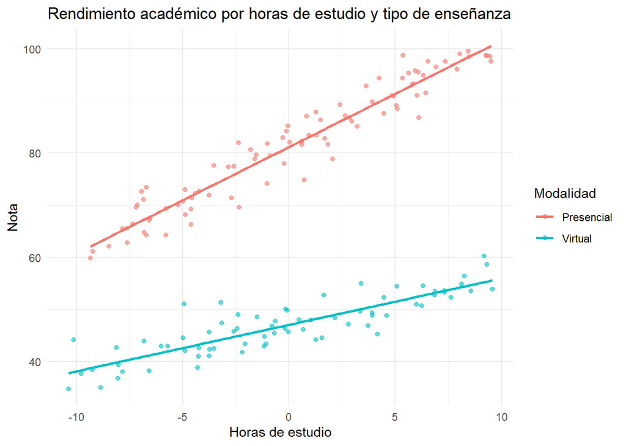

```r
ggplot(datos, aes(x = horas_c, y = nota, color = tipo)) +
  geom_point(alpha = 0.6) +
  geom_smooth(method = "lm", se = FALSE) +
  labs(
    title = "Rendimiento académico por horas de estudio y tipo de enseñanza",
    x = "Horas de estudio",
    y = "Nota",
    color = "Modalidad"
  ) +
  theme_minimal()
```

## 23.12 Interpretación del gráfico:

- En modalidad virtual, el efecto de las horas de estudio es positivo pero menos pronunciado.
- En modalidad presencial, el efecto es más fuerte (pendiente más inclinada), lo que sugiere que estudiar más horas tiene un mayor impacto en este grupo.

## 23.13 Validación de Supuestos

### 23.13.1 Gráfico de residuos estandarizados vs predichos

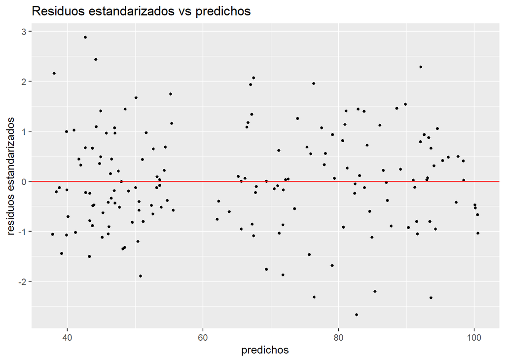

```r
res.pred.df<-data.frame(x=modelo$fitted.values,y=rstandard(modelo))

ggplot(data=res.pred.df,aes(x,y))+
  geom_point(size=1)+
  geom_hline(yintercept = 0, color="red") +
  labs(title = "Residuos estandarizados vs predichos",
       x = "predichos",
       y = "residuos estandarizados")
```

### 23.13.2 Gráfico de residuos estandarizados vs variable regresora

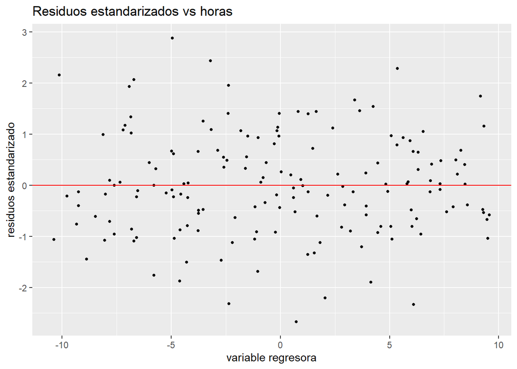

```r
res.reg.df<-data.frame(x1=datos$horas_c,x2=datos$tipo,y=rstandard(modelo))

ggplot(data=res.reg.df,aes(x1,y))+
  geom_point(size=1)+
  geom_hline(yintercept = 0, color="red") +
  labs(title = "Residuos estandarizados vs horas",
       x = "variable regresora",
       y = "residuos estandarizado")
```

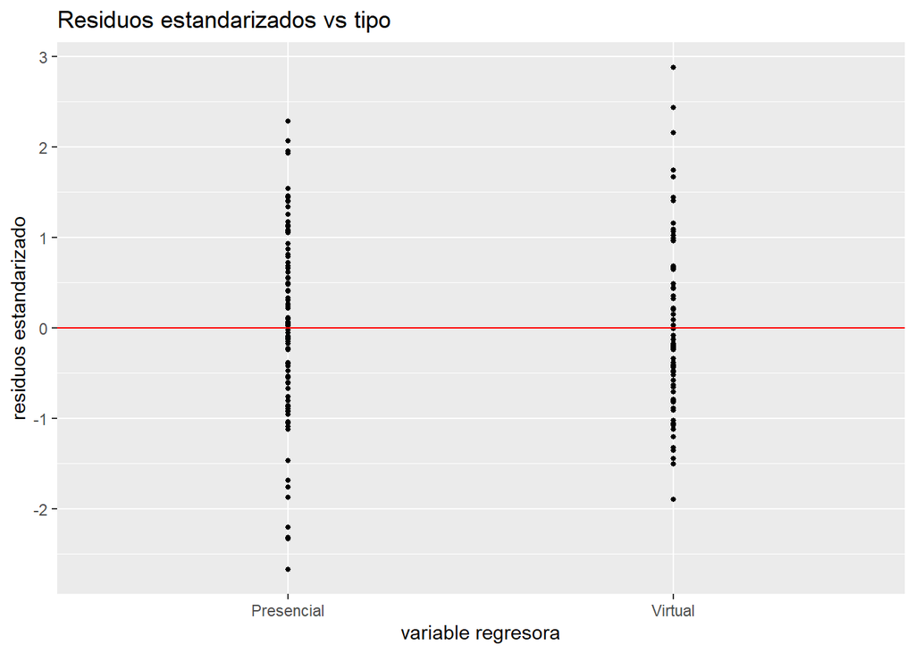

```r
ggplot(data=res.reg.df,aes(x2,y))+
  geom_point(size=1)+
  geom_hline(yintercept = 0, color="red") +
  labs(title = "Residuos estandarizados vs tipo",
       x = "variable regresora",
       y = "residuos estandarizado")
```

### 23.13.3 Normalidad de residuos (QQ-Plot y Shapiro-Wilk)

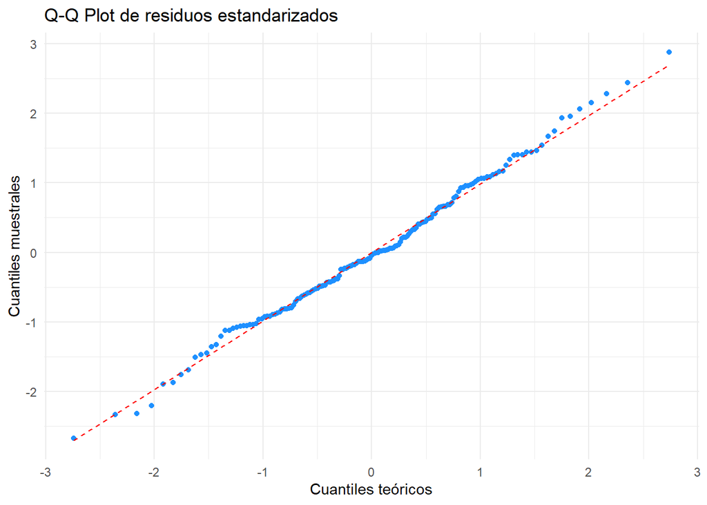

```r
ggplot(data = data.frame(residuos = rstandard(modelo)), aes(sample = residuos)) +
  stat_qq(color = "dodgerblue") +
  stat_qq_line(color = "red", linetype = "dashed") +
  theme_minimal() +
  labs(title = "Q-Q Plot de residuos estandarizados",
       x = "Cuantiles teóricos",
       y = "Cuantiles muestrales")
```

### 23.13.4 Test de normalidad

```r
shapiro.test(residuals(modelo))
```

```
##
##  Shapiro-Wilk normality test
##
## data:  residuals(modelo)
## W = 0.99438, p-value = 0.7897
```

### 23.13.5 Multicolinealidad (VIF)

```r
library(car)
vif(modelo)
```

```
## there are higher-order terms (interactions) in this model
## consider setting type = 'predictor'; see ?vif
```

```
##      horas_c         tipo horas_c:tipo
##     1.822499     1.001749     1.821562
```

## 23.14 Intervalos de Confianza y Predicción

### 23.14.1 Intervalos para coeficientes

```r
confint(modelo, level = 0.95)
```

```
##                          2.5 %      97.5 %
## (Intercept)          80.566848  81.7878725
## horas_c               1.925686   2.1536961
## tipoVirtual         -35.005153 -33.1675992
## horas_c:tipoVirtual  -1.319122  -0.9793695
```

### 23.14.2 Prediccións para un estudiante que estudia 20 horas en virtual

```r
nuevo_dato <- data.frame(horas_c = 20-media, tipo = "Virtual")
predict(modelo, nuevo_dato, interval = "confidence")  # Intervalo para la media
```

```
##        fit      lwr      upr
## 1 51.19228 50.27352 52.11103
```

```r
predict(modelo, nuevo_dato, interval = "prediction")  # Intervalo para un individuo
```

```
##        fit      lwr      upr
## 1 51.19228 45.30019 57.08436
```

# Referencias

Montgomery, Douglas C., Elizabeth A. Peck, and Geoffrey G. Vining. 2006. *Introducción Al Análisis de Regresión Lineal*. 6th ed. Wiley.